# Ecosystems Assessment: Okanogan Highland Ecological Section

Author

Randy Swaty

Published

May 25, 2026

## Location and Background

Principle 6 of the FSC US FSS aims to maximize positive environmental impacts and minimize adverse environmental impacts of management activities occurring within certified management units. Toward this desired outcome, Criterion 6.5 requires the identification and protection or restoration of native ecosystems that are not already adequately represented and protected in the landscape.

This tool serves to support certificate holders with the requirements of Criterion 6.5 related to Representative Sample Areas, but importantly, does not ensure conformance. Additional information gathering and evaluation will most likely be required by certificate holders to ensure conformance with the elements of Criterion 6.5. It is not possible to establish a blanket measurement by which to determine “adequate” protection of all various and complex native ecosystems across the entirety of the conterminous US.

This tool primarily helps with elements of Indicator 6.5.1, and may additionally assist in conformance with Indicators 6.5.2 - 6.5.6.

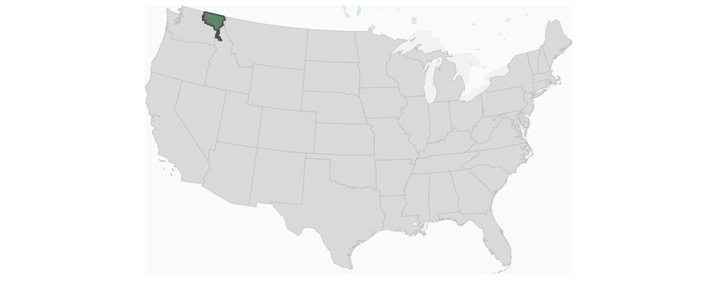

**Key Concepts about the input data from LANDFIRE:**

- The [Biophysical Settings (BpS)](https://landfire.gov/vegetation/bps) data represents the “habitat” of an ecosystem, based on abiotic factors such as soils, surficial geology, slope, elevation and aspect, plus the current climate. Each BpS has a reference document that describes how it looked and functioned prior to European colonization and a state-and-transition model that estimates how much of each “Succession Class” (see below) would have occurred within the habitat based on best approximations of the natural disturbance regime (refered to below as ‘reference’). The BpSs are based on NatureServe’s [Ecological Systems](https://landfire.gov/data-downloads/documents/PCom_2003_Ecol_Systems_US.pdf).
- [Succession Classes (s-class)](https://landfire.gov/vegetation/sclass) are essentially developmental and/or structural stages. There are up to 5 defined for each BpS and are based on lifeform (e.g., broadleaf or needleleaf), and ranges of canopy cover (e.g., 70-80%) and canopy height (e.g., 10-25M ). In addition to modeled estimates of reference percents of each SCL, succession classes are mapped across the US today so that we can compare reference to current amounts.
- [Existing Vegetation Type (EVT)](https://landfire.gov/vegetation/evt) data represents current distribution of NatureServe’s Ecological Systems. Note-because of subsequent review and improvement, BpS and EVT names and lists for particular places may not always match.

**Two ways to compare reference to historical ecosystems with LANDFIRE data**

> First way: exploring succession class percents. This method uses the BpS data to establish the ecosystem habitat, BpS models to estimate reference percentages of each succession class then the succesion class spatial data to quantify current amounts of each s-class. You might get a result that reads such as “within the northern pine-oak BpS there was 17% of class A in the reference period, 10% today”. This is the way LANDFIRE was designed to compare reference and current.

> Second way: comparing the BpS and EVT data. With this method we essentially “stack” the two datasets so that each pixel gets a label for what was there during the reference period and a label for what is there currently. Because the BpS and EVT datasets were not designed to work this way, we are conservative, presenting the topmost BpSs by area, and using “coarse” EVT labels. For example when looking at change for a “Ponderosa Pine” BpS, we might use “Conifer” for the EVT instead of “Rocky Mountain Mixed-Coniferous” for a pixel or collection of pixels. This helps ensure that not too much detail is read into the BpS - EVT comparisons below.

## Explorations using the Biophysical Settings and Succession Class Datasets

### Amount of the most prevelant Biophysical Settings

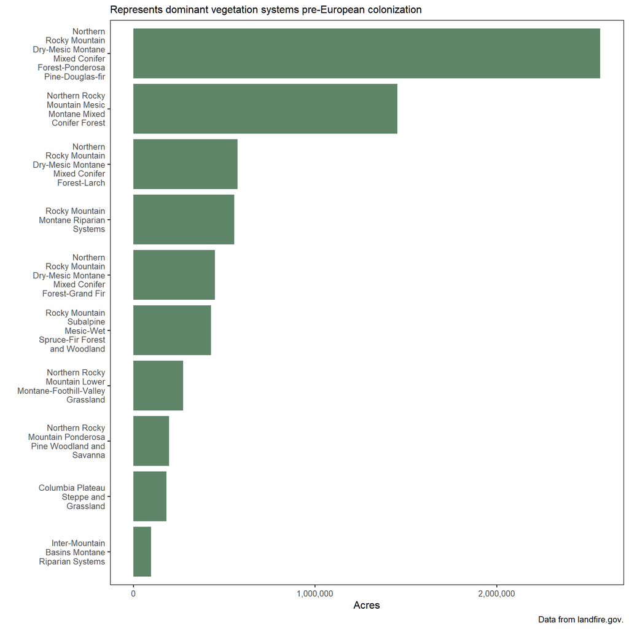

### Succession Classes: Reference vs. Present

Succession classes essentially represent structural stages, defined by ranges of upper-layer canopy cover, height and lifeform (and in some cases leaf form, needle vs. broadleaf). Definitions vary from ecosystem to ecosystem-see table below and BpS descriptions for specifics.

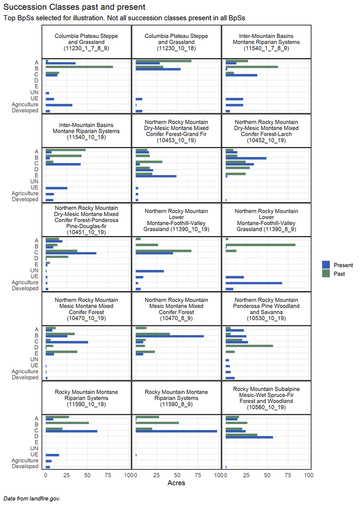

### Historical Disturbance Rates per BpS

In order to estimate historical amounts of succession classes, LANDFIRE used state and transition modeling. The transitions in this context are natural disturbances. By multiplying the modeled annual probability by the mapped amount of an BpS, we can estimate annual disturbance amounts.

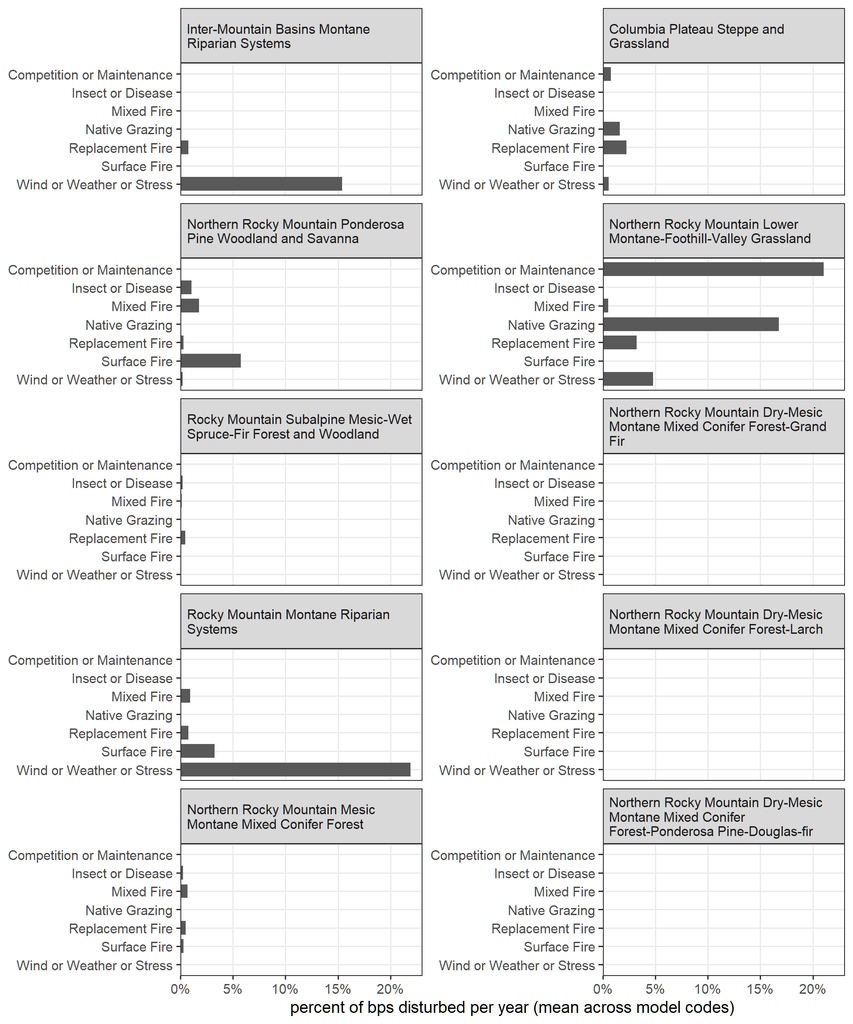

## Explorations focused on the Existing Vegetation Type Datasets

### Protected area status

The GAP status codes are defined as (copied from https://www.usgs.gov/programs/gap-analysis-project/gap-status-code-frequently-asked-questions-faq)

**Gap Status 1:** An area having permanent protection from conversion of natural land cover and a mandated management plan in operation to maintain a natural state within which disturbance events (of natural type, frequency, intensity, and legacy) are allowed to proceed without interference or are mimicked through management.

**Gap Status 2:** An area having permanent protection from conversion of natural land cover and a mandated management plan in operation to maintain a primarily natural state, but which may receive uses or management practices that degrade the quality of existing natural communities, including suppression of natural disturbance.

**Gap Status 3:** An area having permanent protection from conversion of natural land cover for the majority of the area, but subject to extractive uses of either a broad, low intensity type (for example, logging, Off-Highway Vehicle recreation) or localized intense type (for example, mining). It also confers protection to federally listed endangered and threatened species throughout the area.

**Gap Status 4:** There are no known public or private institutional mandates, or legally recognized easements or deed restrictions held by the managing entity to prevent conversion of natural habitat types to anthropogenic habitat types. The area generally allows conversion to unnatural land cover throughout or management intent is unknown.

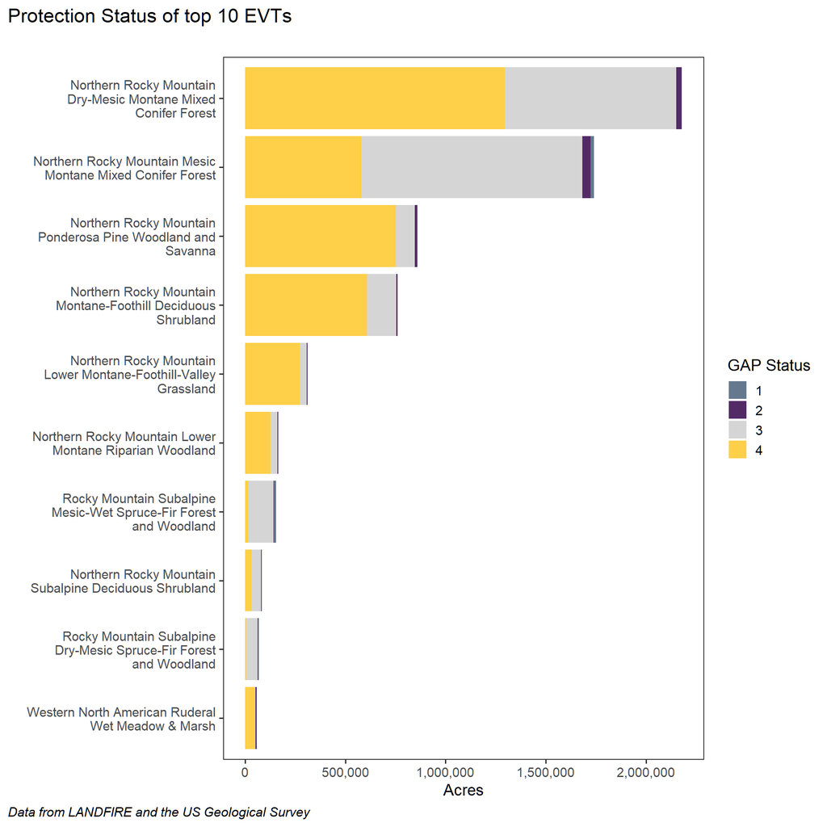

### Comparing BpS to EVT

Northern Rocky Mountain Dry-Mesic Montane Mixed Conifer Forest-Ponderosa Pine-Douglas-fir (56%)

[interactive chart not shown]

Northern Rocky Mountain Mesic Montane Mixed Conifer Forest (32%)

[interactive chart not shown]

Northern Rocky Mountain Dry-Mesic Montane Mixed Conifer Forest-Larch (12%)

[interactive chart not shown]